# BAE 204 - Lab #12: Calculate nitrate removal kinetics in a wetland Instructions

François Birgand

4/8/2021

## Set up

- Go to https://github.com/francoisbirgand/BAE204-removal_kinetics_lab
- Download the whole repository to a directory of your choice
- Open the file “Lab11-removal-kinetics.Rproj”
- Once open, and in the lower right window, in the tab file, open the file “BAE204_LabReport12_yourname.Rmd” and rename it using your name. This is going to be the file you will use to generate your lab report.
- The data provided in this lab comes from an experiment which was part of the MS thesis from Mr. Marc Horstman. Intact sediment mesocosms were obtained from the field, brought back to the lab. Ten centimeters of water were added on top of the sediment, spiked with nitrate, and recirculated at variable velocities. Nitrate concentrations were measured over time.

## Exercise 1: Explore the content of the data and first plot

- In the first chunk, there is only one line right now which reads the data file and stores it into a variable called data.
- In the console, typing `data` will show you what is contained in it.
- The function `names()` gives the names of the different types of data stored in a variable. Using it, you will see that it gives you the names of the columns of this dataset.
- You will see that you have three columns, `X`, `time`, and `conc`.
- Ignore column `X` for now. The time is in seconds and the concentration is in mg N/L.
- In the chunk, Assign in a variable timeday the time expressed in days
- Assign to the variable `conc`, the concentration data
- Assign to the variable `xlimtime` the limits of the experimental time, and to `ylimconc` the limits of the concentration values. You will use this for plotting. For this, you might want to explore the range of the time and concentration data. A function `range()` can help you for this.

### Exercise 1 Report items:

- In this exercise please:
  - Add some text to introduce what the data comes from and which introduces the plot below.
  - In the first chunk, add all requested variable assignment
  - Plot the concentration decrease as a function of time (plot 1)
  - Change the x axis labels to “time in days”
  - Change the y axis label to “nitrate concentrations (mg N/L)”
  - Add a title to the graph
  - Change the default color and symbol of the points to a filled symbol with a background color of your choice (use `?pch` in the console to have access to the help file)
  - If you are lost about how to plot, you may want to look at the [first chunk here](https://francoisbirgand.github.io/blog-flow-and-load-duration-curves.html).

## Exercise 2 : Fitting a first order rate model by transforming data into linear variable

- The first order hypothesis, stipulates that the downward flux of nitrate into the sediment is a first order rate, i.e., proportional to the concentration of nitrate in the water column.
- We have seen in class that one can derive a general exponential equation in this case:

$$C(t)=C_0e^{-\frac{\rho}{D}(t-t_0)}$$

- Where $C(t)$ is the concentration at any time $t$, $C_0$ the initial concentration at $t_0$ , $D$ the water depth, and $\rho$ the mass transfer coefficient
- The only unknown is the mass transfer coefficient ρ and the goal is to find a method to calculate it
- To fit a curve that would go through the points, we need to calculate the unknown parameter ρ.
- But one cannot easily fit an exponential curve through experimental points directly
- We are much better at fitting a straight line when points are generally aligned.
- By modifying the equation above, it is possible to obtain a linear function with time of the type $Z = k \times (t-t_0)$, with $t$ being the time of the above equation. from which it is possible to calculate rho, knowing that the water depth was 0.1 m.
- If you go back to the video and halt it at about 30 min, that equation is written on the board not too far from the equation framed in red

### Exercise 2 Report items:

- In this exercise please:
  - Add a paragraph that introduces the final equation written above with the same letters
  - Report the equation using the coding for that purpose using [this site as a guide](https://francoisbirgand.github.io/tutorial-RMarkdown_instructions.html#editing_equations_in_r_markdown).
  - Add a sentence/paragraph stating how you can transform the previous equation such that you can have new variables as a linear function of time.
  - Fill in, still using the math coding for equations, what $Z=?$ and what $k= ?$
  - Create a new chunk in which you will plot $\ln{\frac{C(t)}{C_0}}$ as a function of $(t-t_0)$. `log()` in `r` stands for natural log `ln`. Adjust the label names accordingly
  - Comment on the general appearence of the plotted points (i.e., do they appear to be in a square root shape, convex, concace, exponential, logarithmic, linear, etc.?)
  - State what the variable $k$ might represent on the graph you just plotted

## Exercise 3 : Fitting a first order rate model by calculating mass transfer coefficient

By now, you have understood that the points of the previous plot are pretty much aligned, and that it is very tempting to fit a line through them. This is what we are about to do. In `r`, the `function` that can fit a line through points is called `lm()` standing for *linear model*.

- To automatically calculate the ρ value, you need will to use the lm() function in R standing for “linear model”
- The `lm()` function works as shown in the chunk below. I have created dummy x and y variables
- You see that `names(linreg)` gives all the variables behind the variable `linreg`, including `coefficients`, which give the slope and the intercept of the linear fit. In our case here, we have asked using `lm(y~x+0)` that the intercept be 0. So `linreg$coefficients[1]` gives you all the values contained in the variable (there is only one value for us here), and using `linreg$coefficients[1]` yields the value for the slope of the line of your variable linreg. The function `abline()` automatically draws the linear fit through the points.

```r
x=c(1,2,3,4,5,6,7)
y=c(1,2,3.4,4.1,4.9,6.1,7)
plot(x,y)
linreg <- lm(y~x+0)
names(linreg)
```

```
##  [1] "coefficients"  "residuals"     "effects"       "rank"
##  [5] "fitted.values" "assign"        "qr"            "df.residual"
##  [9] "xlevels"       "call"          "terms"         "model"
```

```r
linreg$coefficients
```

```
##        x
## 1.012143
```

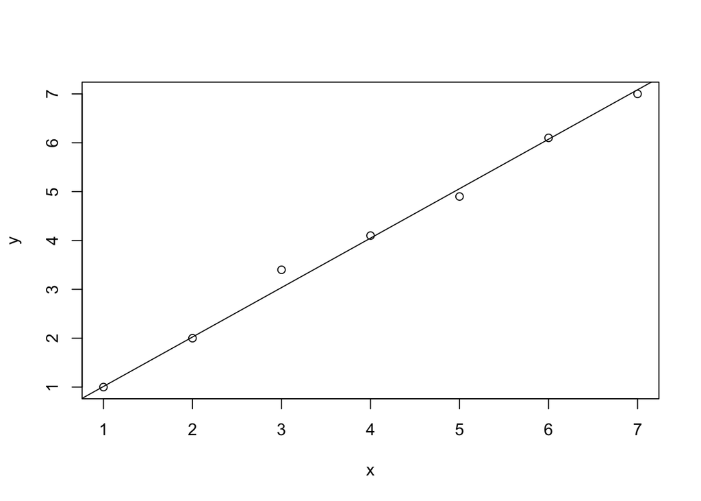

```r
abline(linreg)
```

### Exercise 3 Report items:

- In this exercise please:
  - Create a new chunk in which you will plot (again) $\ln{\frac{C(t)}{C_0}}$ as a function of $(t-t_0)$ and apply the function `lm()` as illustrated above to calculate the slope of the linear curve that goes through the points, and to which you will add the straight line that will fit through your points
  - Add a sentence/paragraph explaining with your own words how you can use the `slope` of the straight line fitting through the points of the plot $\ln{\frac{C(t)}{C_0}}$ as a function of $(t-t_0)$ to calculate ρ.
  - Express in a separate equation how you can express ρ as a function of the `slope` and the water depth $D$.
  - Calculate and report the mass transfer coefficient $\rho_{0cm.s}$ in the text with three significant digits and the proper unit corresponding for this stagnant water.
  - Create a new chunk where you will plot the original concentration data as a function of time, but this time, you will add the curve with the exponential concentration decrease as a function of time, using your calculated ρ value. For this you just add a new line on the original first, which represent $C(t)=f(t)$. To make the exponential line look good, you should make t, the time in this case to have a pretty high resolution. I suggest that you use something like `t=seq(0,2,by=(1/24))`. This generates a sequence of number from 0 to 2, with intervals of 1 day/24, or hourly resolution. Do not forget that to add an additional series on a plot, you new to add `plot(new=TRUE)`, and make sure you set the same limits for the x and y axis both both the points and your exponential curve.

## Exercice 4: Treatment time for stagnant water

Now that you have a model, you can extrapolate results and calculate indicators or efficiencies you would not have been able to calculate from the experimental data. Using your model, you can calculate the concentration decrease that would occur after a given period of time, or the time it would take for concentrations to decrease given and intial and a final concentration.

- The goal here is
  - to calculate how long it would have taken for this stagnant water to have nitrate concentration decrease from 7 mg N/L to 0.3 mg/L
  - to calculate the percentage reduction that would occur after 1 day of residence time

### Exercice 4 Report items:

- In this exercise please:
  - In a properly written paragraph, you explain how you can calculate how long it would have taken for this stagnant water to have nitrate concentration decrease from 7 mg N/L to 0.3 mg N/L.
  - In this paragraph, you will have to express in an equation written in proper mathematical symbols $t$ as a function of $C_f$, the final concentration (which would equal 0.3 mg N/L in our case here; do not use numbers in this equation, just letters) $C_i$ the initial concentration, $D$ the water depth, and $\rho$ the mass trahsfer coefficient.
  - Add a sentence/paragraph reporting (using embedded code and with three significant digits) the time $t_{0cm.s}$ calculated using your equation for this stagnant water.
  - Add a paragraph, the proper equation to calculate the removal percentage $RP$ calculated as $\frac{c_{beg}-c_{end}}{c_{beg}}$ and expressed as function of $\rho$, $D$, and $t (= 1 day)$. Report the removal percentage $RP_{0cm.s}$ for this stagnant water using %age 2 digit values.

## Exercise 5: Treatment time for water recirculated at 3 cm/s

- Using the file “Exp03_Rep3_U3.csv” (see chunk below), plot the exponential curve, calculate and report $\rho_{3cm.s}$, as well as the time it would have taken for this recirculated water to have nitrate concentration decrease from 7 mg N/L to 0.3 mg/L.

```r
data2<-read.csv(file="https://raw.githubusercontent.com/francoisbirgand/BAE204-removal_kinetics_lab/master/Exp03_Rep3_U3.csv",header = TRUE) #Reads file into table format
```

### Exercise 5 : Report items:

- In this exercise please:
  - Add a small paragraph that describes what you are doing now and what the difference is with what you did previously. The goal obviously here is to evaluate whether the velocity of recirculation has an impact of the ρ values and therefore treatment.
  - Report a plot of the concentration decrease as a function of time with your exponential fit to it. Calculate and report $\rho_{3cm.s}$, as well as the time $t_{3cm.s}$ it would have taken for this recirculated water to have nitrate concentration decrease from 7 mg N/L to 0.3 mg/L. Calculate the Removal Percentage ($RP_{3cm.s}$) 2 digit values for water residing one day above this sediment and recirculated at 3 cm/s.

## Exercise 6: Discuss your observations

### Exercise 6 : Report items:

- In this exercise please:
  - Compare the $\rho_{0cm.s}$ and $\rho_{3cm.s}$, the $RP_{0cm.s}$ and $RP_{3cm.s}$ values, and the $t_{0cm.s}$ and $t_{3cm.s}$ values.
  - Discuss the differences between the treatment times and what you think is the dominant factor that drives this difference. Discuss in as many details as possible what recirculation or water does as it flows over an uneven surface. Discuss how recirculation might or might not have increased D<sub>w</sub> and D<sub>N</sub>. I expect about a dozen sentences at a minimum here.
  - Discuss the fitting of the data using 1st order kinetics for the experiment where water was recirculated at 3 cm/s. Do you think it is a good fit? If yes/no, why? What do you think the consequences are on the predicted treatment capacity of the wetland?